# CSE204 - Introduction to Machine Learning - Lab Session 3: k-Nearest Neighbors

[CSE204-2019](https://moodle.polytechnique.fr/course/view.php?id=7862) Lab session #03

Jérémie DECOCK - Adrien EHRHARDT

## Objectives

- Implement the *k-Nearest Neighbors* algorithm
- Use it to solve classification and regression problems
- Define the decision boundaries
- Explain the weaknesses of this algorithm

## Imports and tool functions

```python
colab_requirements = [
    "matplotlib>=3.1.2",
    "pandas>=0.25.3",
    "numpy>=1.18.1",
    "scikit-learn>=0.22.1",
    "scipy>=1.4.1",
    "nose>=1.3.7"
]
import sys, subprocess
def run_subprocess_command(cmd):
    # run the command
    process = subprocess.Popen(cmd.split(), stdout=subprocess.PIPE)
    # print the output
    for line in process.stdout:
        print(line.decode().strip())

if "google.colab" in sys.modules:
    for i in colab_requirements:
        run_subprocess_command("pip install " + i)
```

```python
import numpy as np

import matplotlib.pyplot as plt
from matplotlib.colors import ListedColormap

import pandas as pd
import sklearn.neighbors
from sklearn.utils import shuffle

from scipy.spatial import Voronoi, voronoi_plot_2d
```

```python
def gen_2d_classification_samples(n_samples = 20, nclass = 3):

    cov = np.diag([2., 2.])

    x1 = np.random.multivariate_normal(mean=[0., 0.], cov=cov, size=n_samples)
    y1 = np.full(n_samples, 1, dtype=np.int)

    x2 = np.random.multivariate_normal(mean=[4., 0.], cov=cov, size=n_samples)
    y2 = np.full(n_samples, 2, dtype=np.int)

    x3 = np.random.multivariate_normal(mean=[2., 4.], cov=cov, size=n_samples)
    y3 = np.full(n_samples, 3, dtype=np.int)

    if nclass == 3:
        X = np.concatenate([x1, x2, x3])
        y = np.concatenate([y1, y2, y3])
    elif nclass == 2:
        X = np.concatenate([x1, x2])
        y = np.concatenate([y1, y2])
    else:
        raise Error

    df = pd.DataFrame(X, columns=['x1', 'x2'])
    df['y'] = y

    df = shuffle(df).reset_index(drop=True)

    return df
```

```python
cmap_light = ListedColormap(['#FFAAAA', '#AAFFAA', '#AAAAFF'])
cmap_bold = ListedColormap(['#FF0000', '#00FF00', '#0000FF'])

def plot_2d_classification_samples(dataframe, model=None, voronoi=False):
    plt.figure(figsize=(8, 8))

    df = dataframe  # make an alias

    ERROR_MSG1 = "The `dataframe` parameter should be a Pandas DataFrame having the following columns: ['x1', 'x2', 'y']"
    assert df.columns.values.tolist() == ['x1', 'x2', 'y'], ERROR_MSG1

    ERROR_MSG2 = "The `dataframe` parameter should be a Pandas DataFrame having the following labels (in column 'y'): [1, 2, 3]"
    labels = pd.unique(df.y).tolist()
    labels.sort()
    assert labels == [1, 2, 3] or labels == [1, 3] or labels == [1, 2], ERROR_MSG2

    if model is not None:
        if voronoi:
            # Compute the Voronoi cells

            vor = Voronoi(df[['x1', 'x2']])

            # Plot the Voronoi diagram

            fig = voronoi_plot_2d(vor, show_vertices=False, show_points=False)
            fig.set_size_inches(8, 8)

        # Compute the model's decision boundaries

        h = .02  # step size in the mesh

        x_min, x_max = df.x1.min() - 1, df.x1.max() + 1
        y_min, y_max = df.x2.min() - 1, df.x2.max() + 1

        xx, yy = np.meshgrid(np.arange(x_min, x_max, h),
                             np.arange(y_min, y_max, h))

        Z = model.predict(np.c_[xx.ravel(), yy.ravel()])
        Z = Z.reshape(xx.shape)

        # Plot the model's decision boundaries

        plt.pcolormesh(xx, yy, Z, cmap=cmap_light, alpha=0.5)

    # Plot also the training points
    plt.scatter(df.x1, df.x2, c=df.y, cmap=cmap_bold, edgecolor='k', s=30)
    plt.xlabel(r"$x_1$", fontsize=16)
    plt.ylabel(r"$x_2$", fontsize=16)
```

## Nearest Neighbor algorithm

Today you will implement one of the simplest (but quite powerful) machine learning algorithm: the *Nearest Neighbor* algorithm and its extension the *k-Nearest Neighbors* algorithm (or *kNN*). Both can be used for classification and regression tasks. We'll also cover Logistic Regression.

Considering a dataset $\mathcal{D}=\{(\mathcal{x}_i, y_i)_{i=1,\dots,n}\}$ of $n$ labeled examples, the *Nearest Neighbor* model assigns an input vector $\boldsymbol{x}$ to the label $y_{\arg\min_{i=1,\dots, n}d(x, x_i)}$ of its closest neighbor in $\mathcal{D}$.

The distance function $d$ is used to define what is the closest neighbor. This can be any metric measure but the *Minkowski distance* (especially the classical Euclidian distance $d_2$) is the most common choice. It is defined as follow:

$$d_q: \mathbb{R}^p \times \mathbb{R}^p \to \mathbb{R}$$$$d_q(\boldsymbol{u}, \boldsymbol{v}) = ||\boldsymbol{u} - \boldsymbol{v}||_q = \left( \sum_{j=1}^p |u_j - v_j|^q \right)^{1/q}$$

When $q=2$, $d_q$ is the *Euclidian distance*

$$d_2(\boldsymbol{u}, \boldsymbol{v}) = \sqrt{\sum_{j=1}^{p} (u_j - v_j)^2}$$

When $q=1$, $d_q$ is the *Manhattan distance*

$$d_1(\boldsymbol{u}, \boldsymbol{v}) = \sum_{j=1}^{p} |u_j - v_j|$$

When $q=\infty$, $d_q$ is the *Tchebychev distance*

$$d_{\infty}(\boldsymbol{u}, \boldsymbol{v}) = \max_{j=1,\dots,p} |u_j - v_j|$$

### Exercise 1

We consider the following dataset (where 'x1' and 'x2' are examples features and where 'y' is the examples label):

```python
data = [[0, 0, 1],
        [0, 1, 1],
        [1, 1, 2],
        [1, 0, 3]]

df = pd.DataFrame(data, columns=['x1', 'x2', 'y'])
df
```

|  | x1 | x2 | y |
| --- | --- | --- | --- |
| 0 | 0 | 0 | 1 |
| 1 | 0 | 1 | 1 |
| 2 | 1 | 1 | 2 |
| 3 | 1 | 0 | 3 |

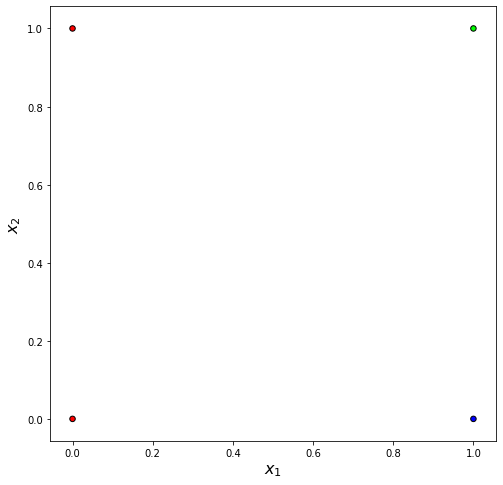

```python
plot_2d_classification_samples(df)
```

#### Question 1

What label will be predicted by the Nearest Neighbor algorithm for the point $x = \pmatrix{0 \\ 0.5}$ ?

Red points (class `1`) are both obviously closer.

#### Question 2

If you have $n$ examples in $p$ dimensions in the dataset, what is the training error of the Nearest Neighbor algorithm (in classification) ? Why ?

0 because the nearest neighbor of each example $x_i$ in the training dataset is the example $x_i$ itself. Thus there is no classification error for these examples.

### Exercise 2

Consider this new dataset (where 'volume (mL)' and 'caffeine (g)' are the examples features and where 'drink' is the label):

```python
data = [[250, 0.025, 'tea'],
        [100, 0.01,  'tea'],
        [125, 0.05,  'coffee'],
        [250, 0.1,   'coffee']]

df = pd.DataFrame(data, columns=['volume (mL)', 'caffeine (g)', 'drink'])
df
```

|  | volume (mL) | caffeine (g) | drink |
| --- | --- | --- | --- |
| 0 | 250 | 0.025 | tea |
| 1 | 100 | 0.010 | tea |
| 2 | 125 | 0.050 | coffee |
| 3 | 250 | 0.100 | coffee |

#### Question 1

Use the Nearest Neighbor method to predict the label of a 125mL drink having 0.015g of caffeine.

The nearest example is $(125 ; 0.050)$. Thus the label of a 125mL drink having 0.015g of caffeine is "coffee".

#### Question 2

What is wrong with this prediction ? How to solve this problem ?

Actually, the predicted drink is more probably a "tea" (considering the caffeine feature).

The prediction is made on the volume and the caffeine is not considered because these two variables are not normalized!

Thus example's value of these two variables have to be normalized to be comparable (i.e. transformed to be contained in the same range).

## Nearest Neighbor method with Scikit Learn

Let's play with the Scikit Learn implementation of the Nearest Neighbor algorithm. The official documentation is there: https://scikit-learn.org/stable/modules/neighbors.html

### Classification

We begin with a "toy" **classification problem**.

Use the `gen_2d_classification_samples()` function (defined above) to generate a dataset.

```python
df = gen_2d_classification_samples(n_samples=20)
df.head()
```

|  | x1 | x2 | y |
| --- | --- | --- | --- |
| 0 | 1.124872 | 3.811048 | 3 |
| 1 | 0.210289 | 0.394681 | 1 |
| 2 | 5.788767 | 0.361287 | 2 |
| 3 | 0.107827 | -0.931052 | 1 |
| 4 | 0.731931 | 2.755557 | 3 |

Here, examples are defined in $\mathbb{R}^2$ (features are stored in columns 'x1' and 'x2'). Example's labels are defined in the 'y' column.

The 'y' column contains three possible labels: "1", "2" and "3" respectively represented by the red, green and blue colors in the following figure.

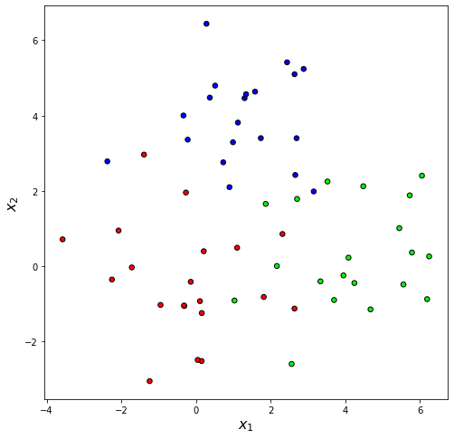

```python
plot_2d_classification_samples(df)
```

Thus this toy problem is a multiclass classification problem.

Once the dataset is ready, let's make the classifier and train it with the following code:

```python
model = sklearn.neighbors.KNeighborsClassifier(n_neighbors=1)
```

```python
model.fit(X=df[['x1', 'x2']], y=df['y'])
```

```
KNeighborsClassifier(algorithm='auto', leaf_size=30, metric='minkowski',
                     metric_params=None, n_jobs=None, n_neighbors=1, p=2,
                     weights='uniform')
```

### Exercise 3

#### Question 1

Use the `model.predict()` function to guess the class of the following points:

$$x_{p1} = \pmatrix{-2 \\ 2}, x_{p2} = \pmatrix{2 \\ 6}, x_{p3} = \pmatrix{6 \\ 0}$$

Store the result in `model_predictions`.

```python
### BEGIN SOLUTION
model_predictions = model.predict([[-2., 2.],
               [2., 6.],
               [6., 0.]])
### END SOLUTION
```

```python
### BEGIN HIDDEN TESTS
np.testing.assert_array_equal(model_predictions, model.predict([[-2., 2.],
               [2., 6.],
               [6., 0.]]))
### END HIDDEN TESTS
```

#### Question 2

Is the training step (`model.fit()` function) longer to execute than the prediction step (`model.predict()` function) ? Why ?

No. `model.fit()` does nothing in Nearest Neighbor models as they have nothing to "learn" (i.e. these models have no parameter to optimize).

The `model.predict()` function does all the job: compute distances with examples in the dataset and find the closest example to the predicted one. This function may be long to execute if there are many examples in the dataset.

#### Question 3

The next cell shows the decision boundary of the model. Explain what is a decision boundary in classification.

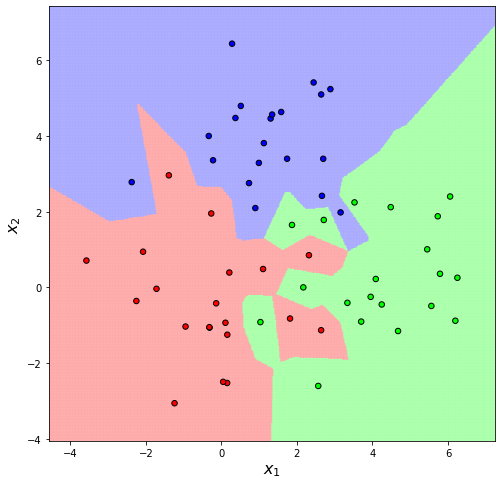

```python
plot_2d_classification_samples(df, model=model)
```

This is a subspace of the feature space $\mathcal{X}$ that partitions it into sets that defines the affiliations to each class:

- all $\boldsymbol{x}$ point in red areas will be labeled "1" (red) by the model
- all $\boldsymbol{x}$ point in green areas will be labeled "2" (green) by the model
- all $\boldsymbol{x}$ point in blue areas will be labeled "3" (blue) by the model

The decision boundaries are the boundaries of these areas.

#### Question 4

The next cell generates the *Voronoï diagram* of the dataset. What does this figure illustrates about the Nearest Neighbor method?

The Voronoï diagram makes a partition of the feature space $\mathcal{X}$. Each partition is a *cell*. What do cells represent?

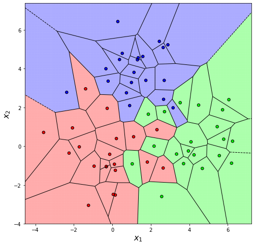

```python
plot_2d_classification_samples(df, model=model, voronoi=True);
```

There is one "cell" per example of $\mathcal{D}$. Each cell defines the area of influence of these examples (called *seeds*): any predicted point $\boldsymbol{x}$ in a cell will receive the same label than its seed example.

### Regression

After the "toy" classification problem, let's work on a toy **regression problem**.

The next cell generates a dataset (where 'x' is the feature and 'y' the label to predict).

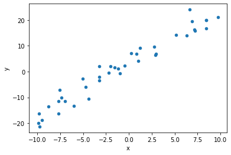

```python
N_SAMPLES = 40
x = np.random.uniform(low=-10., high=10., size=N_SAMPLES)
y = 2. * x + 3. + np.random.normal(scale=3., size=x.shape)

df = pd.DataFrame(np.array([x, y]).T, columns=['x', 'y'])
df.plot.scatter(x='x', y='y');
```

Once the dataset is ready, let's make the regressor and train it with the following code:

```python
model = sklearn.neighbors.KNeighborsRegressor(n_neighbors=1)
```

```python
model.fit(df[['x']], df['y'])
```

```
KNeighborsRegressor(algorithm='auto', leaf_size=30, metric='minkowski',
                    metric_params=None, n_jobs=None, n_neighbors=1, p=2,
                    weights='uniform')
```

### Exercise 4

Use the `model.predict()` function to guess the class of the following points:

$$x_{p1} = \pmatrix{-2}, x_{p2} = \pmatrix{2}, x_{p3} = \pmatrix{6}$$

Store it in `model_predictions_bis`.

```python
### BEGIN SOLUTION
model_predictions_bis = model.predict([[-2.],
               [2.],
               [6.]])
### END SOLUTION
```

```python
### BEGIN HIDDEN TESTS
np.testing.assert_array_equal(model_predictions_bis, model.predict([[-2.],
               [2.],
               [6.]]))
### END HIDDEN TESTS
```

### Plot the model's decision function

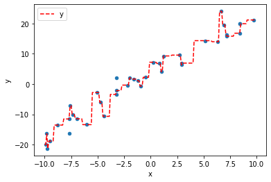

```python
x_pred = np.arange(-10, 10, 0.1).reshape(-1, 1)
y_pred = model.predict(x_pred)

df_pred = pd.DataFrame(np.array([x_pred.flatten(), y_pred.flatten()]).T, columns=['x', 'y'])

ax = df.plot.scatter(x='x', y='y')
df_pred.plot(x='x', y='y', style='r--', ax=ax);
```

### Exercise 5

Do you think this model *generalizes* well? Why?

This model learns the trend of the data and this is desired. At the same time, we can observe that the model overfits the data. It learns the noise contained in the dataset, and fits too closely to the observed, limited set of data points. This is **not** desired because it will lead to poor results on unknown data.

Therefore, we can conclude that this model does not generalize well and overfitting will affect the quality of predictions on new observations.

## Logistic Regression (Gradient Descent)

```python
df = gen_2d_classification_samples(n_samples = 100, nclass = 2)
```

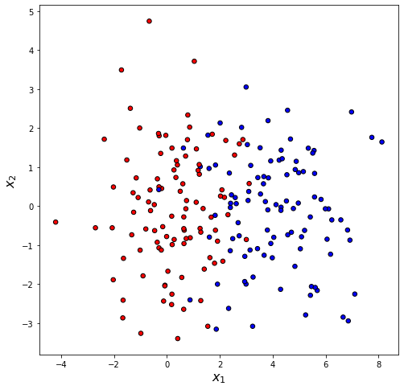

```python
plot_2d_classification_samples(df)
```

Logistic regression is very similar to linear regression in so far as it is a **parametric model** which aims at finding a parameter $\theta^\star$ such as $f_{\boldsymbol{\theta}}: \boldsymbol{x} \mapsto y$ provides a good "link" between input vectors $\boldsymbol{x} \in \mathbb{R}^p$ and output values $y \in \{0,1\}$ in a *learning set* $\mathcal{D} = \{(y^{(i)}, \boldsymbol{x^{(i)}})\}_{1 \leq i \leq n}$ of $n$ examples:

$$ \theta^\star = \arg\!\min E(\theta, \mathcal{D}), $$

where $E(\theta, \mathcal{D}) = - \sum_{i=1}^n \ln p_{\theta}(y^{(i)} | x^{(i)})$.

Fortunately, logistic regression is a rather simple model which states:

$$ p_{\theta}(1 | x^{(i)}) = \frac{1}{1+\exp{(-\theta^T x^{(i)})}} $$

This formulation yields the convexity of the loss function $E(\theta, \mathcal{D})$, which means $\theta^\star$ exists, is unique, and can be obtained by minimizing $E$.

### Exercise 6

Complete the following `gradient_descent` function implemented in the last lab to work for logistic regression.

**Hint**: only the gradient needs to be changed.

```python
X = np.array([np.ones((df.shape[0])), df.x1, df.x2])
y = np.array(df.y) - 1
```

```python
def gradient_descent(X, y, eta=0.001, max_iteration=10000, initial_theta=None):

    if initial_theta is None:
        # The initial solution is selected randomly
        theta = np.random.normal(loc=0, scale=10, size=[3, 1])
    else:
        theta = initial_theta

    grad_list = []      # Keep the gradient of all iterations
    theta_list = []     # Keep the solution of all iterations

    for i in range(max_iteration):
        # Perform the gradient descent here
        ### BEGIN SOLUTION
        grad = np.dot(X, 1/(1+np.exp(-np.dot(X.T, theta))) - y.reshape(-1,1))
        theta = theta - eta * grad / X.shape[1]     # Update the current solution

        grad_list.append([grad[0][0], grad[1][0], grad[2][0]])       # Keep the gradient
        theta_list.append([theta[0][0], theta[1][0], theta[2][0]])   # Keep the solution
        ### END SOLUTION

    return grad_list, theta_list
```

As a side note, you might have noticed that we divide here `grad` by `n` (the number of samples). It's merely some kind of convention:

- If you divide by n, you have the mean-sample loss, so if you are generating data, you will converge as fast / slow (keeping eta constant) regardless of the number of samples you have, which in a way seems "consistent".
- If you don't, you use the total loss to update the parameters, so it's also arguably "logic" to converge faster with a constant eta, since you have more information.

For example, scikit let's you choose (normalize option): https://scikit-learn.org/stable/modules/generated/sklearn.metrics.log_loss.html

And by the way, for logistic regression, the "optimal" learning rate, which would be Newton Raphson's method (https://thelaziestprogrammer.com/sharrington/math-of-machine-learning/solving-logreg-newtons-method), is somehow also linked to the number of samples.

It's also the reason why you might have witnessed much faster convergence than here with your implementation (i.e. without dividing).

```python
grad_list, theta_list = gradient_descent(X, y, eta = 0.01)
```

Let's see if it has converged by plotting the parameters:

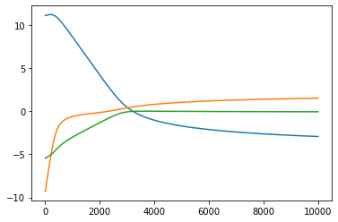

```python
plt.plot([theta[0] for theta in theta_list])
plt.plot([theta[1] for theta in theta_list])
plt.plot([theta[2] for theta in theta_list])
```

Let's see the decision boundary, i.e. the half-spaces where each label is predicted.

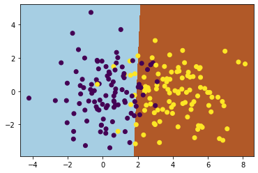

```python
x_min, x_max = np.array((df.x1, df.x2))[0, :].min() - .5, np.array((df.x1, df.x2))[0, :].max() + .5
y_min, y_max = np.array((df.x1, df.x2))[1, :].min() - .5, np.array((df.x1, df.x2))[1, :].max() + .5
h = .02  # step size in the mesh
xx, yy = np.meshgrid(np.arange(x_min, x_max, h), np.arange(y_min, y_max, h))
Z = 1/(1+np.exp(-np.dot(np.c_[np.ones((len(xx.ravel()))), xx.ravel(), yy.ravel()], theta_list[9999])))
plt.pcolormesh(xx, yy, (Z.reshape(xx.shape) > 0.5)*1, cmap=plt.cm.Paired)
plt.scatter(df.x1, df.x2, c=y)
```

## Logistic Regression (scikit-learn)

### Exercise 7

Let's do the same using scikit-learn!

Similar to the previous lab, logistic regression belongs to the linear model module, and provides among others the `fit` and `predict` methods. Use the `fit` method to compare the coefficients obtained with scikit-learn and your gradient descent.

**Beware of the `C` parameter**, which corresponds to L2 regularization (see docs).

```python
model = sklearn.linear_model.LogisticRegression(C=1e9)

### BEGIN SOLUTION
model.fit(df[['x1', 'x2']], df[['y']])
### END SOLUTION
```

```
LogisticRegression(C=1000000000.0, class_weight=None, dual=False,
                   fit_intercept=True, intercept_scaling=1, l1_ratio=None,
                   max_iter=100, multi_class='auto', n_jobs=None, penalty='l2',
                   random_state=None, solver='lbfgs', tol=0.0001, verbose=0,
                   warm_start=False)
```

```python
model.intercept_[0]
```

```
-3.745431997953839
```

```python
theta_list[9999][0]
```

```
-2.9312047170060676
```

```python
model.coef_[0].tolist()
```

```
[1.8504573849638581, -0.09584759249800988]
```

```python
theta_list[9999][1:3]
```

```
[1.5095415002333068, -0.06254586833152893]
```

## k-Nearest Neighbors algorithm

The *Nearest Neighbor* method is very sensitive to noise: if an example in $\mathcal{D}$ is wrongly labeled or positioned, all points in its Voronoï cell will be wrong too. The *k Neareast Neighbor* fix this weakness by considering for each prediction the label of several neighbors instead of just one.

Considering a dataset $\mathcal{D}=\{(\mathcal{x}_i, y_i)_{i=1,\dots,n}\}$ of $n$ labeled examples and a meta parameter $k \in \mathbb{N}*$, the *$k$ Nearest Neighbors* model assigns an input vector $\boldsymbol{x}$ to the label $y_{\arg\min_{i=1,\dots, n}d(x, x_i)}$ of its $k$ closest neighbor in $\mathcal{D}$. Let's write $\mathcal{N}_k(\boldsymbol{x})$ the set of the $k$ nearest neighbors of $\boldsymbol{x}$ in $\mathcal{D}$.

- For classification problems, the label assigned to $\boldsymbol{x}$ is the **most represented label** among the nearest neighbors (vote) $$f(\boldsymbol{x}) = \arg\max_c \sum_{i: x_i \in \mathcal{N}_k(\boldsymbol{x})} \delta(y_i, c)$$
- For regression problems, the label assigned to $\boldsymbol{x}$ is computed based on the **mean** of the labels of its nearest neighbors $\mathcal{N}_k(\boldsymbol{x})$ $$f(\boldsymbol{x}) = \frac{1}{k} \sum_{i: x_i \in \mathcal{N}_k(\boldsymbol{x})} y_i$$

### Exercise 8

We consider the following dataset (where `x1` and `x2` are the example features and where `y` is the example label):

```python
data = [[1, 2, '+'],
        [2, 1, '+'],
        [2, 2, '-'],
        [2, 3, '+'],
        [3, 1, '-'],
        [3, 2, '+']]

df = pd.DataFrame(data, columns=['x1', 'x2', 'y'])
df
```

|  | x1 | x2 | y |
| --- | --- | --- | --- |
| 0 | 1 | 2 | + |
| 1 | 2 | 1 | + |
| 2 | 2 | 2 | - |
| 3 | 2 | 3 | + |
| 4 | 3 | 1 | - |
| 5 | 3 | 2 | + |

#### Question 1

Draw this dataset (it is OK to draw it on a sheet of paper).

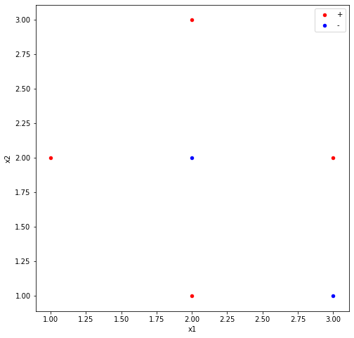

```python
### BEGIN SOLUTION
ax = df.loc[df.y == '+'].plot.scatter(x='x1', y='x2', color='red', label="+", figsize=(8,8))
df.loc[df.y == '-'].plot.scatter(x='x1', y='x2', color='blue', label="-", ax=ax);
### END SOLUTION
```

#### Question 2

Draw the decision boundary of a Nearest Neighbor model (i.e. 1NN - also OK on a sheet of paper).

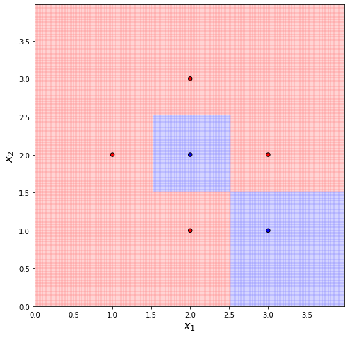

```python
### BEGIN SOLUTION
df.loc[df.y == '-', "y"] = 3
df.loc[df.y == '+', "y"] = 1
df.y = df.y.astype('int')
model = sklearn.neighbors.KNeighborsClassifier(n_neighbors=1)
model.fit(df[['x1', 'x2']], df['y'])
plot_2d_classification_samples(df, model=model)
### END SOLUTION
```

#### Question 3

Draw the decision boundary of a 3 Nearest Neighbor model (i.e. 3NN)

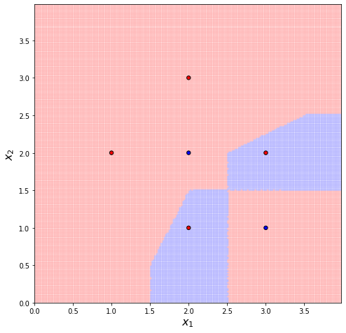

```python
### BEGIN SOLUTION
model = sklearn.neighbors.KNeighborsClassifier(n_neighbors=3)
model.fit(df[['x1', 'x2']], df['y'])
plot_2d_classification_samples(df, model=model)
### END SOLUTION
```

#### Question 4

How many errors these two classifiers make on the training dataset ?

- with $k = 1$: no error
- with $k = 3$: 4 errors

#### Question 5

What label these two classifiers predict for the point $x = \pmatrix{4 \\ 0.5}$ ?

## k-Nearest Neighbor (kNN) with Scikit Learn

### Classification

First we generate the dataset.

```python
df = gen_2d_classification_samples()
```

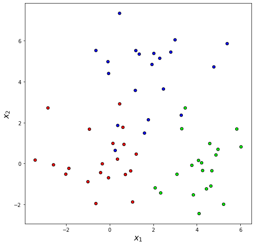

```python
plot_2d_classification_samples(df)
```

Then we instantiate the classifier, train it and plot the decision boundaries:

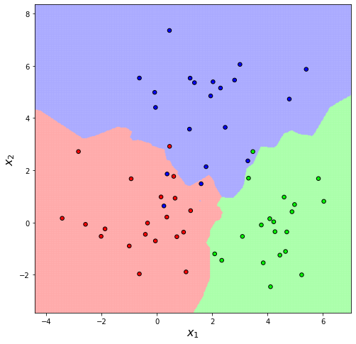

```python
model = sklearn.neighbors.KNeighborsClassifier(n_neighbors=5)

model.fit(df[['x1', 'x2']], df['y'])

plot_2d_classification_samples(df, model=model)
```

### Exercise 9

The `n_neighbors` parameter provided to the model's constructor `KNeighborsClassifier` sets the number of neighbors to consider for each prediction (i.e. `n_neighbors` this is the '$k$' of kNN).

#### Question 1

Change the value of this parameter and observe what happen. What is the influence of the number of neighbors on the boundaries ?

Large $k$ produce "smoother" boundaries. In general, a model with e.g. $k=5$ is less influenced by the noise contained in the dataset than a model with $k < 5$ i.e. it generalize better.

If $k \geq n$ (with $n$ the number of elements in the dataset $\mathcal{D}$) then all predicted points have the label of the most represented class (see question 4 in case of equals representations).

#### Question 2

When you face a very noised dataset (wrong labels, misplaced points, ...), should you increase or decrease $k$ ?

#### Question 3

Is the Voronoi diagram useful for the kNN case (i.e. when $k>1$) ?

No.

#### Question 4

Plot the decision boundary with $k=2$ and describe what append in case of equal vote?

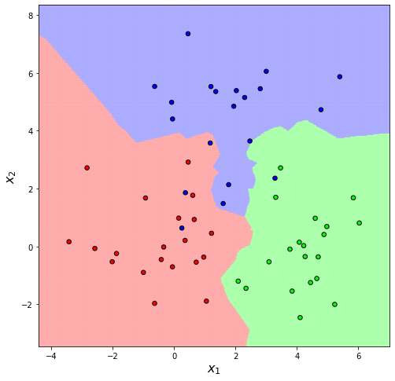

```python
### BEGIN SOLUTION
model = sklearn.neighbors.KNeighborsClassifier(n_neighbors=2)
model.fit(df[['x1', 'x2']], df['y'])
plot_2d_classification_samples(df, model=model)
### END SOLUTION
```

An arbitrary choice is made.

In Scikit Learn:

- the first class (red) is always selected in case of equal vote with the other two
- the second class (green) is always selected in case of equal vote with the third one (blue)

#### Question 5

Add the `weights = "distance"` parameter in `KNeighborsClassifier`'s constructor. What changes can you observe on the decision boundary? Explain how labels are computed with this new parameter.

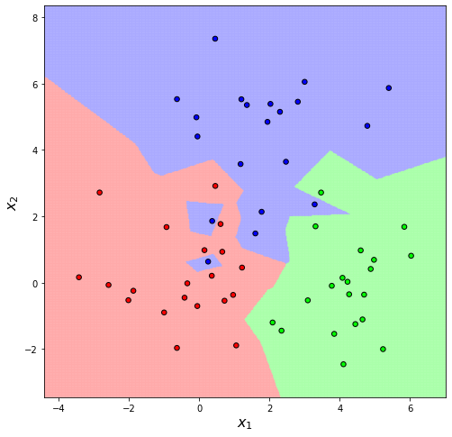

```python
### BEGIN SOLUTION
model = sklearn.neighbors.KNeighborsClassifier(n_neighbors=2, weights="distance")
model.fit(df[['x1', 'x2']], df['y'])
plot_2d_classification_samples(df, model=model)
### END SOLUTION
```

With this parameter enabled, the influence of the k nearest neighbors is weighted by their proximity to the point $\boldsymbol{x}$ to predict.

It has a disadvantage to make models more sensitive to the noise contained in $\mathcal{D}$.

### Regression

First we generate the dataset.

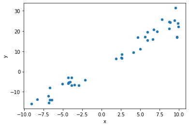

```python
N_SAMPLES = 40
x = np.random.uniform(low=-10., high=10., size=N_SAMPLES)
y = 2. * x + 3. + np.random.normal(scale=3., size=x.shape)

df = pd.DataFrame(np.array([x, y]).T, columns=['x', 'y'])
df.plot.scatter(x='x', y='y');
```

Then we instantiate the classifier, train it and plot the decision boundaries:

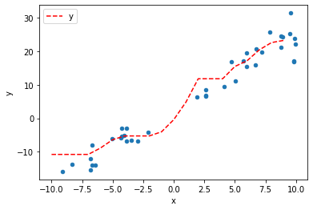

```python
n_neighbors = 10

model = sklearn.neighbors.KNeighborsRegressor(n_neighbors)

model.fit(df[['x']], df['y'])

x_pred = np.arange(-10, 10, 1).reshape(-1, 1)
y_pred = model.predict(x_pred)

df_pred = pd.DataFrame(np.array([x_pred.flatten(), y_pred.flatten()]).T, columns=['x', 'y'])

ax = df.plot.scatter(x='x', y='y')
df_pred.plot(x='x', y='y', style='r--', ax=ax);
```

### Exercise 10

The `n_neighbors` parameter provided to the model's constructor `KNeighborsClassifier` sets the number of neighbors to consider for each prediction (i.e. `n_neighbors` this is the '$k$' of kNN).

#### Question 1

Change the value of this parameter and observe what happens. What is the influence of the number of neighbors on the decision function ?

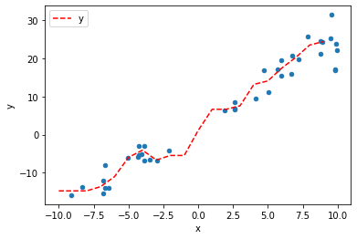

```python
### BEGIN SOLUTION
n_neighbors = 2
model = sklearn.neighbors.KNeighborsRegressor(n_neighbors)
model.fit(df[['x']], df['y'])
x_pred = np.arange(-10, 10, 1).reshape(-1, 1)
y_pred = model.predict(x_pred)
df_pred = pd.DataFrame(np.array([x_pred.flatten(), y_pred.flatten()]).T, columns=['x', 'y'])
ax = df.plot.scatter(x='x', y='y')
df_pred.plot(x='x', y='y', style='r--', ax=ax);
### END SOLUTION
```

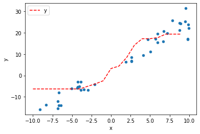

```python
### BEGIN SOLUTION
n_neighbors = 20
model = sklearn.neighbors.KNeighborsRegressor(n_neighbors)
model.fit(df[['x']], df['y'])
x_pred = np.arange(-10, 10, 1).reshape(-1, 1)
y_pred = model.predict(x_pred)
df_pred = pd.DataFrame(np.array([x_pred.flatten(), y_pred.flatten()]).T, columns=['x', 'y'])
ax = df.plot.scatter(x='x', y='y')
df_pred.plot(x='x', y='y', style='r--', ax=ax);
### END SOLUTION
```

In one hand, a model with a small $k$ (e.g. $k=2$) is more influenced by the noise contained in the dataset i.e. it has poorer generalization performance (i.e. poor results on unknown data): this is an **overfitted** model.

In the other hand, if $k$ is too large compared to the number of available examples in $\mathcal{D}$ (e.g. if $k=20$ here) it won't be capable to fit local trends and will have poor results too: this is an **underfitted** model.

Here, $k=10$ seems to be a good compromise.

#### Question 2

When you face a very noised dataset (wrong labels, misplaced points, ...), should you increase or decrease $k$ ?

There is a tradeoff to find. But a model with a small $k$ is more influenced by the noise contained in the dataset.

## Bonus

### Exercise 11

Solve the Titanic problem with the k Nearest Neighbors method. Reuse the code of the first lab session.

```python
### BEGIN SOLUTION
titanic = pd.read_csv("https://raw.githubusercontent.com/adimajo/polytechnique-cse204-2019-releases/master/data/titanic_train.csv")
titanic = titanic.drop(['Name', 'Ticket', 'Cabin', 'PassengerId'], axis=1)
titanic = titanic.dropna()
titanic['Embarked'] = titanic['Embarked'].map({'S': 0, 'C': 1, 'Q': 2}).astype(int)
titanic['Sex'] = titanic['Sex'].map({'male': 0, 'female': 1}).astype(int)
X = titanic.drop("Survived", axis=1)
Y = titanic["Survived"]
X_train = X.iloc[:-10]
Y_train = Y.iloc[:-10]
X_test = X.iloc[-10:]
Y_test = Y.iloc[-10:]
n_neighbors = 5
knn = sklearn.neighbors.KNeighborsClassifier(n_neighbors)
knn.fit(X_train, Y_train)
knn.score(X_test, Y_test)
### END SOLUTION
```

```
0.8
```

### Exercise 12

This function should return the sequence of predicted labels.

```python
from math import sqrt


def knn(data, xpred, n_neighbors=2):
    distances = np.zeros((nrow(data), nrow(xpred)))
    for x in range(0, nrow(data)):
        for y in range(0, nrow(xpred)):
            distances[x, y] = sqrt(sum([(x_1 - x_2)**2 for (x_1, x_2) in (x, y)]))

    for y in range(0, nrow(xpred)):
        for i in range(n_neighbors):
            neighbors.append(distances[i][0])

    return()
```